# Exploratory Data Analysis of Officer Traffic Stops

On a first glance at the data, we can see that this data covers traffic stops by police officers in Charlotte, North Carolina over the year 2016. Let’s explore first the race, gender and years of service of officers.

| Officer Race | Officer Gender | Count |
| --- | --- | --- |
| White | Male | 45,939 |
| Black/African American | Male | 11,708 |
| White | Female | 4,861 |
| Asian / Pacific Islander | Male | 3,731 |
| Hispanic/Latino | Male | 2,198 |
| Black/African American | Female | 606 |
| Not Specified | Male | 338 |
| Hispanic/Latino | Female | 321 |
| American Indian/Alaska Native | Male | 221 |
| Not Specified | Female | 90 |
| Native Hawaiian/Oth Pac Island | Male | 62 |

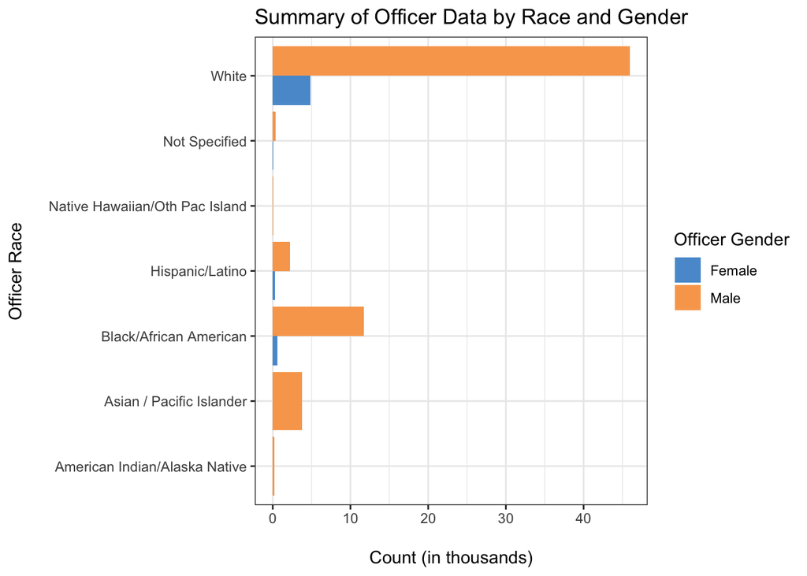

| Officer Race | Gender | Average Years of Service |
| --- | --- | --- |
| Asian / Pacific Islander | Male | 12 |
| White | Male | 12 |
| Black/African American | Male | 11 |
| American Indian/Alaska Native | Male | 9 |
| White | Female | 9 |
| Black/African American | Female | 8 |
| Hispanic/Latino | Male | 7 |
| Native Hawaiian/Oth Pac Island | Male | 7 |
| Hispanic/Latino | Female | 4 |

[figure not shown]

Now, let us summarise and visualize the officer data by their respective CMPD divisions.

| CMPD Division | Count |
| --- | --- |
| South Division | 8,699 |
| Providence Division | 7,634 |
| North Division | 6,782 |
| Westover Division | 6,642 |
| Hickory Grove Division | 6,383 |
| Eastway Division | 5,833 |
| University City Division | 5,302 |
| Steele Creek Division | 4,788 |
| Independence Division | 4,613 |
| Metro Division | 3,652 |
| Central Division | 3,148 |
| Freedom Division | 3,130 |
| North Tryon Division | 3,041 |

Let us know visualize the officer data that we have previously summarized.

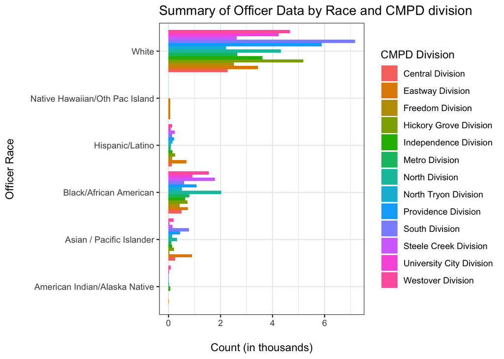

**We observe that the highest number of stops were being conducted by officers of *white* race from the “South Division”, followed by *Providence Division* and *Hickory Grove Division*. A lot of stops were also being conducted by *black/African American* officers.**